# jakerobbins301208633project1

Jake Robbins 301208633 robbins@sfu.ca

October 30, 2018

## Requirements, etc..

```r
set.seed(1234)
require(DataExplorer)
require(dplyr)
require(ROCR)
require(e1071)
require(rpart)
require(class)
require(randomForest)
load("druguse.Rdata")
```

## Question One: Exploratory Data Analysis

We shall begin with a cursory glance at the background of respondents in our data and their overall use of illegal drugs:

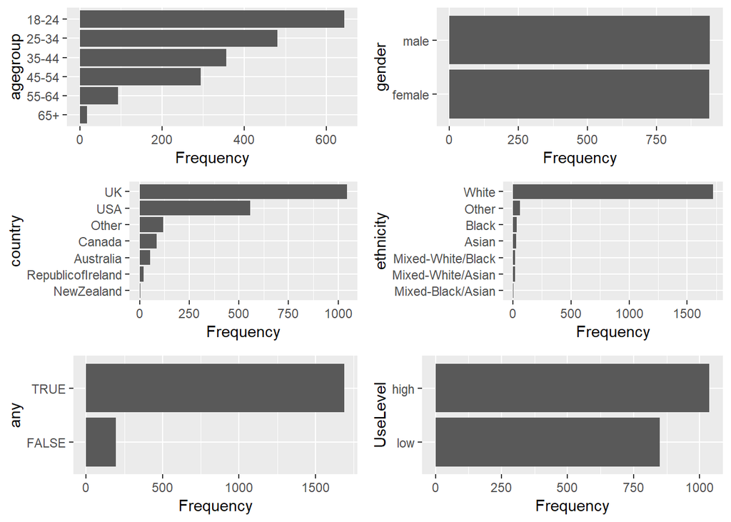

```r
plot_bar(druguse)
```

We can immediately see that the data is overwhelmingly made up of respondents from the UK and USA with white ethnicity, so we may not have enough data from other countries or ethnicities to determine the existence of meaningful relationships between these variables and drug usage. Also of note is that our sample skews toward a younger age range; a quick internet search for population pyramids of the USA and UK show that the age range 65+ is greatly underrepresented in our data compared to the general population. We also can note that the vast majority of those in our data set reported having used one or more illegal drugs at least once in their lives. We can break down by age group who has used any illegal substance in their lifetime.

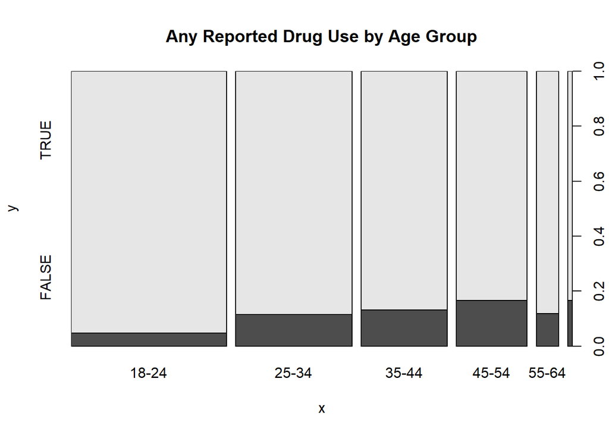

```r
plot(druguse$agegroup, druguse$any, main='Any Reported Drug Use by Age Group')
```

It is apparent from the above graph that generally, those in older age groups were less likely to have tried any illicit substances. Considering those who are older have had more time to try drugs we may have expected the reverse relationship to the one observed. This would seem to indicate that younger people are considerably more likely to try drugs than previous generations were. Also, the possibility should be considered that drug users may be more likely to die prematurely and thus the data from older demographics suffers survivorship bias.

Now we’ll look over the rest of the data:

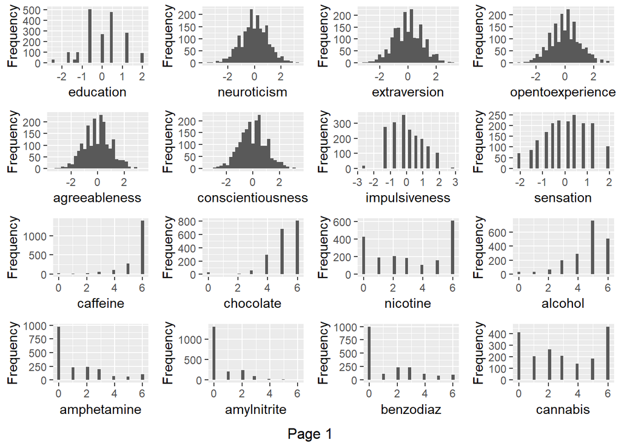

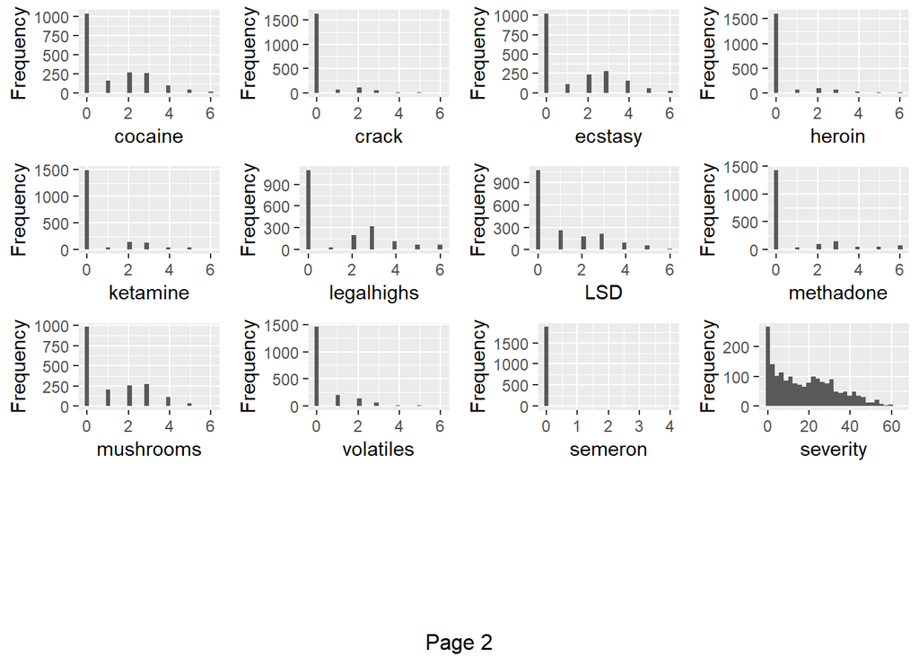

```r
plot_histogram(druguse)
```

The first two rows are measures of education level and personality traits. The third shows usage of legal substances. The rest of the histograms show reported illegal drug use, with the very last histogram being of the ‘severity’ variable.

We can see there were very few false use reportings of the fake control drug ‘Semeron’, which should give some confidence in the reliability of the reported data (though this says nothing of the possibility of underreporting).

With the exception of Cannabis, each illegal substance was most often ‘never used’ by a large margin. Considering that the majority of respondents had reported using at least one illegal drug, it may be beneficial to determine if this phenomenon is mostly because most had used cannabis but no other illegal substance, or to what extent it is due to respondents taking one, or just a few, types of illegal substance but never using the rest. I.e. it may be the case that we have people who exclusively use heroin or LSD but almost never both.

To investigate this possibility, we can check how well the different drugs correlate with oneanother:

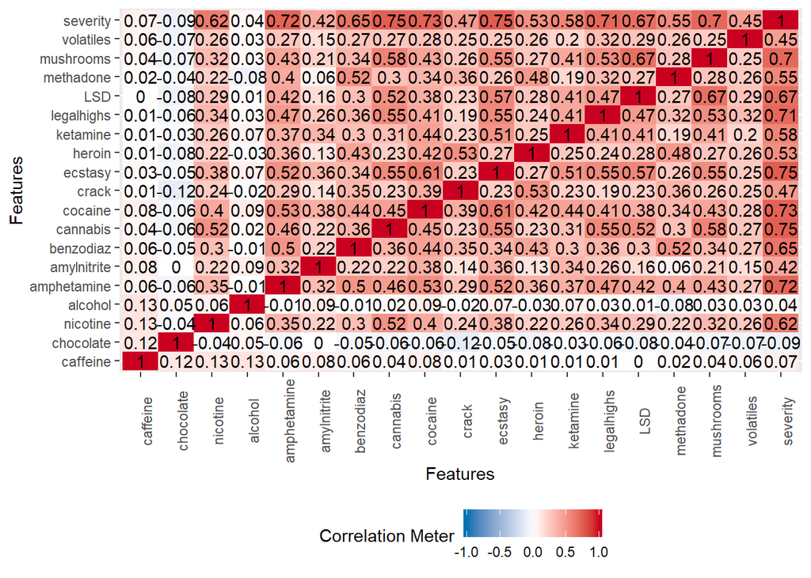

```r
plot_correlation(druguse[c(13:30,33)])
```

Cleary, we can see that use of any illegal drug correlates with use of all the other illegal drugs, but also that, with the exception of nicotine, there is no meaningful correlation between the use of legal drugs (not including so-called ‘legal highs’) and use of illicit substances. This means that those who use any illicit drugs are likely to use others as well. I shall investigate this further at the end of Question Four.

We may additionally observe that Crack is more highly correlated with heroin than with any other substance and vice versa, and that cocaine is considerably more correlated with ecstasy than it is with crack. This indicates we may be able to find different ‘groupings’ within the data: different demographics may have ‘preference’ for (or easier access to) specific drugs, among other possible relationships. E.g. LSD and Mushrooms share the highest correlation in our data between illicit substances and are both hallucinogens. It may also be the case that different personality types favour certain drugs.

Note that the ‘Severity’ outcome is also included in the above correlation matrix. Alcohol use has little correlation with a high severity measure, but Cannabis has a comparitively high correlation value. To better understand this result, observe the following two plots of the use of both substances versus severity:

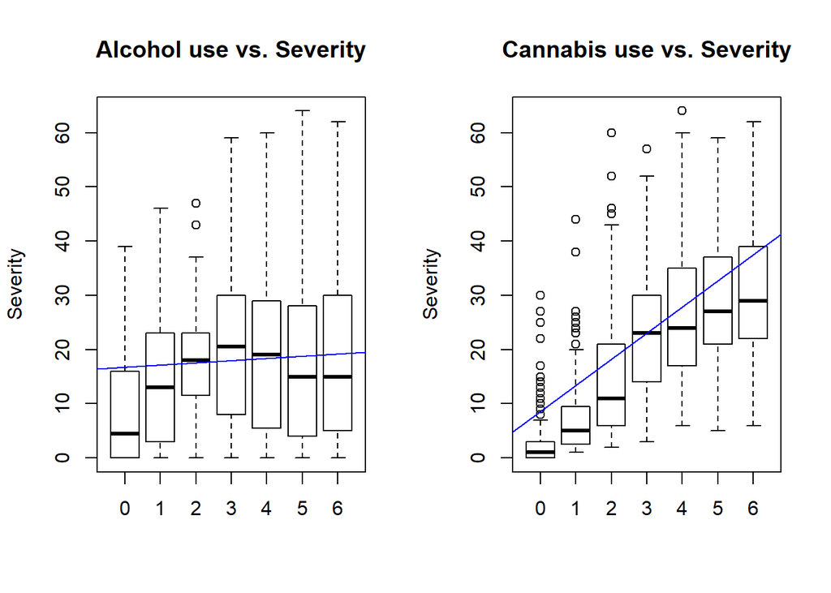

```r
par(mfrow=c(1,2))
plot(as.factor(druguse$alcohol),druguse$severity, main='Alcohol use vs. Severity', ylab= 'Severity')
abline(lm(druguse$severity ~ druguse$alcohol),col="blue")
plot(as.factor(druguse$cannabis),druguse$severity, main='Cannabis use vs. Severity',ylab='Severity')
abline(lm(druguse$severity ~ druguse$cannabis),col="blue")
```

It should be kept in mind that the values used for reported drug use only indicate the length of time since the most recent use of each drug only, and that nothing is said of the dosage or past frequency of use. For instance, it could be the case that we have one respondent that drinks a glass a wine about once a week and thus reported a ‘5’, while another respondent who used to drink excessively for decades but has been sober for just over a year reports a ‘3’.

Now we shall look to see if there could be any meaningful relationships in our data between background characteristics and reported drug use.

First, we’ll examine by age and gender:

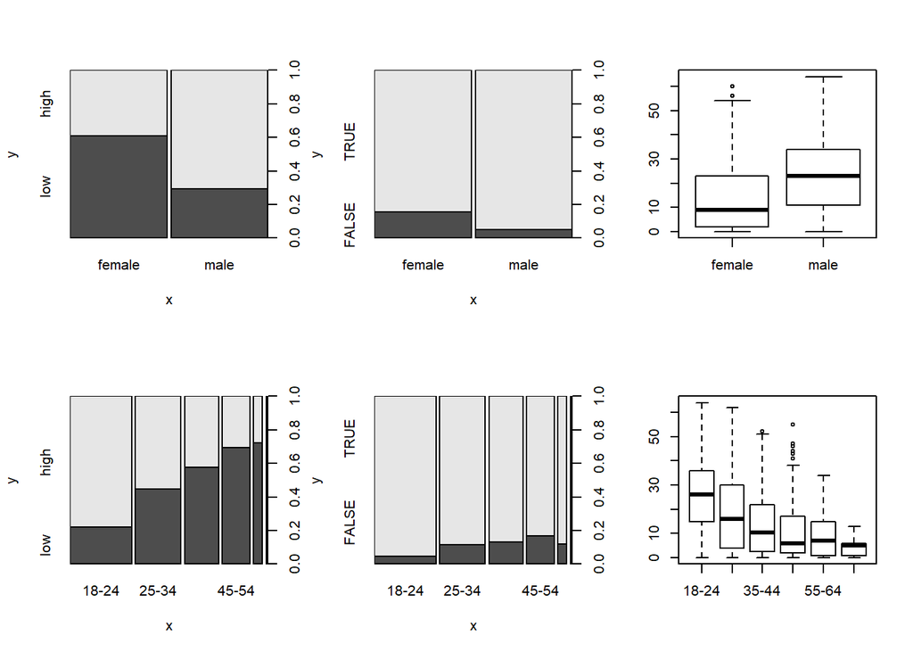

```r
par(mfrow=c(2,3))
plot(druguse$gender,druguse$UseLevel)
plot(druguse$gender,druguse$any)
plot(druguse$gender,druguse$severity)


plot(druguse$agegroup,druguse$UseLevel)
plot(druguse$agegroup, druguse$any)
plot(druguse$agegroup,druguse$severity)
```

We see that Males were more likely to have reported using drugs, had higher levels of use and higher severity ratings on average. We also find (as we did earlier) that drug use is generally higher in younger people with worse severity.

The breakdown of drug use level by country and ethnicity follows:

```r
table(druguse$country, druguse$UseLevel)
```

```
##
##                     low high
##   Australia           8   46
##   Canada             30   57
##   NewZealand          1    4
##   Other              27   91
##   RepublicofIreland   5   15
##   UK                716  328
##   USA                62  495
```

```r
table(druguse$ethnicity, druguse$UseLevel)
```

```
##
##                     low high
##   Asian              19    7
##   Black              26    7
##   Mixed-Black/Asian   0    3
##   Mixed-White/Asian   8   12
##   Mixed-White/Black  10   10
##   Other              19   44
##   White             767  953
```

Interestingly, the UK has relatively very low usage of drugs, especially compared to the US.

We now look at education:

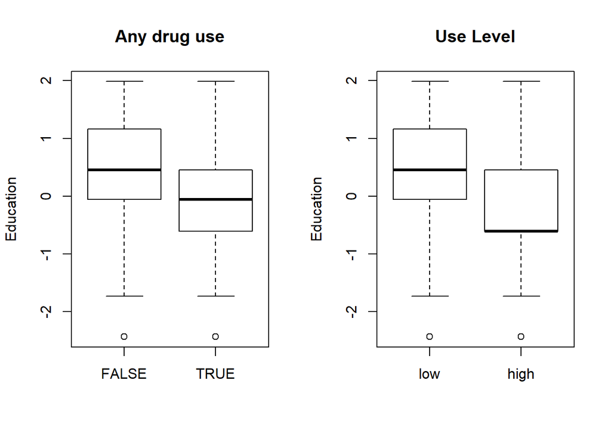

```r
par(mfrow=c(1,2))
plot(druguse$any,druguse$education,main='Any drug use',ylab='Education')
plot(druguse$UseLevel,druguse$education,main='Use Level', ylab='Education')
```

Higher education is associated with lower usage of drugs.

Finally, let’s investigate the personality measures as predictors of illicit drug use, use level and severity:

```r
x<-druguse[6:12]

#Correlations for personality and Severity
cor(x,druguse$severity)
```

```
##                          [,1]
## neuroticism        0.18368677
## extraversion      -0.03223595
## opentoexperience   0.37633799
## agreeableness     -0.20880386
## conscientiousness -0.31622783
## impulsiveness      0.36884350
## sensation          0.49455028
```

```r
#Correlations for personality and Uselevel
cor(x,as.numeric(druguse$UseLevel))
```

```
##                          [,1]
## neuroticism        0.13967826
## extraversion      -0.03882249
## opentoexperience   0.37108294
## agreeableness     -0.18077992
## conscientiousness -0.31499336
## impulsiveness      0.33004475
## sensation          0.47205494
```

```r
#Correlations for personality and 'Any' illicit use
cor(x,as.numeric(druguse$any))
```

```
##                          [,1]
## neuroticism        0.11083930
## extraversion      -0.04946062
## opentoexperience   0.17087510
## agreeableness     -0.13842763
## conscientiousness -0.20504911
## impulsiveness      0.19872844
## sensation          0.24115028
```

We see that neuroticism, openess to experience, sensation and impulsiveness are correlated with use of illicit substances, whereas agreeableness and consientousnous are negatively correlated. Extraversion has no significant correlation at all.

## Question Two: Use Level Prediction

We shall now use a logistic regression method to predict the value of the ‘UseLevel’ variable as ‘high’ or ‘low’ given only an individual’s background and personality measurements.

```r
#First, we split the data into a training set and a test set.
myperm=sample(nrow(druguse))
drugtrain=druguse[myperm[1:1500],]
drugtest=druguse[myperm[1501:1885],]


fm = as.formula(drugtrain[c(34,1:12)]) #selects uselevel to be predicted by first 12 variables.

model <- glm(fm  , family=binomial(link='logit'),data=drugtrain) # models on training set


guess=predict(model, drugtest, type="response") # uses model to predict on test set.
```

We can plot our model’s prediction of the test dataset as follows:

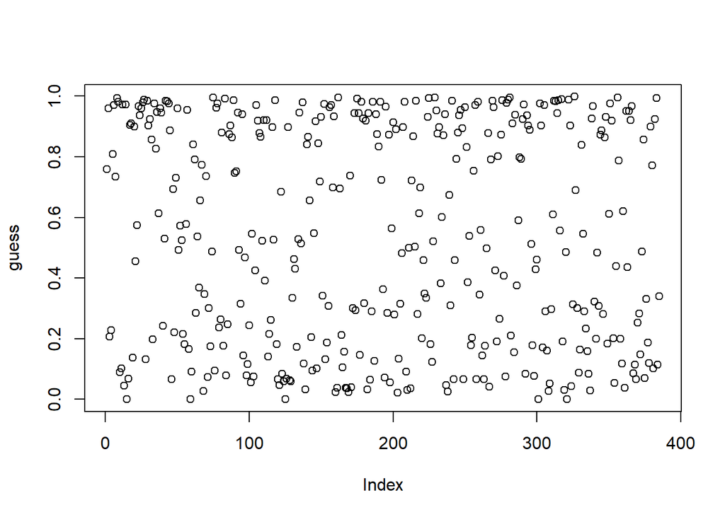

```r
plot(guess)
```

We’ll choose a cutoff value of .5. Anything higher is to be predicted as ‘high’ for UseLevel. Let’s see how this performs:

```r
predictedlvl=ifelse(guess>.5, 'high','low')

res=table( predictedlvl, drugtest$UseLevel )
matrix(data=res, nrow=2, ncol=2,
       dimnames=list(Predicted=c("high", "low"), Actual=c("low", "high")))
```

```
##          Actual
## Predicted low high
##      high  29  172
##      low  144   40
```

We can see from the above table how well our model performs in predicting ‘low’ and ‘high’ values for UseLevel. We can calculate an accuracy as follows:

```r
TP=sum(predictedlvl=='high' & drugtest$UseLevel=='high')
TN=sum(predictedlvl=='low' & drugtest$UseLevel=='low')
accuracy = (TP+TN)/length(drugtest$UseLevel)
accuracy
```

```
## [1] 0.8207792
```

Was our choice of .5 as a cutoff appropriate? Using a ROC we can adjust this parameter to achieve different TPR,FPR,TNR,FNR values and also to maximize overall accuracy.

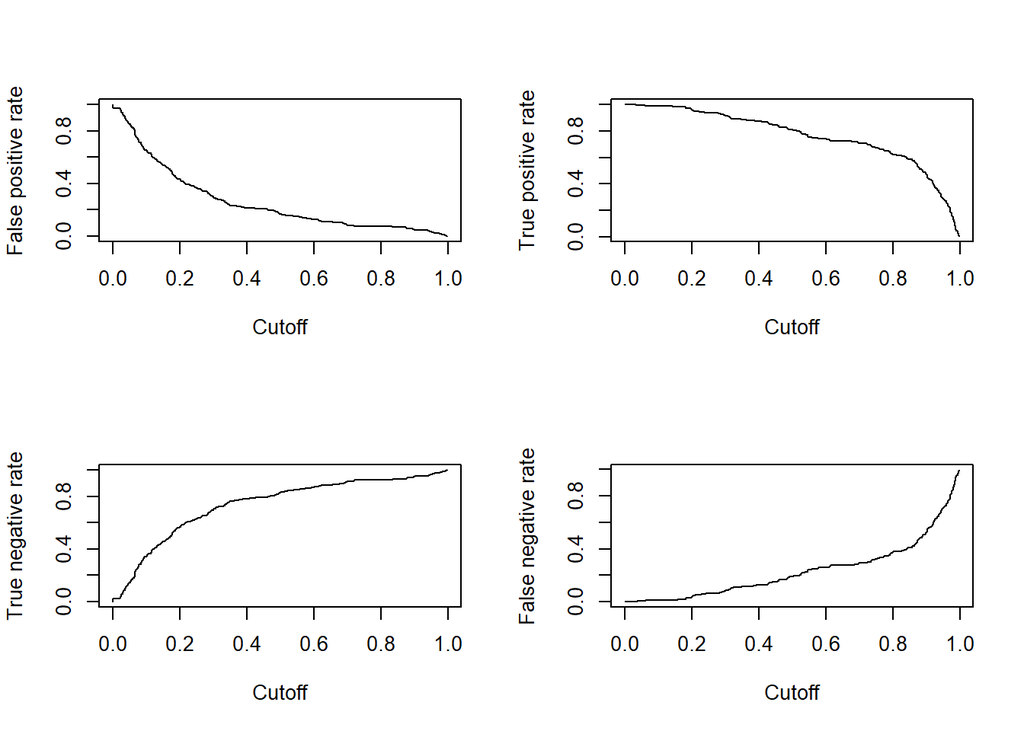

```r
pr <- prediction(guess,drugtest$UseLevel , label.ordering = c('low','high'))


par(mfrow=c(2,2))
fpr <- performance(pr, measure = "fpr")
plot(fpr)
tpr <- performance(pr, measure = "tpr")
plot(tpr)
tnr <- performance(pr, measure = "tnr")
plot(tnr)
fnr <- performance(pr, measure = "fnr")
plot(fnr)
```

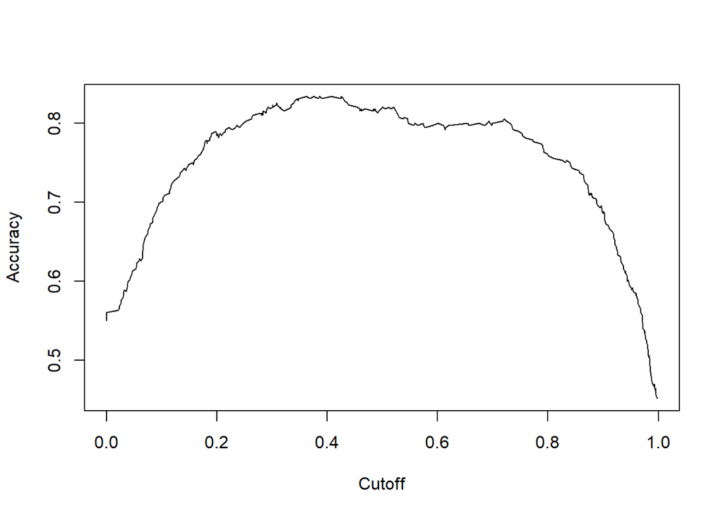

```r
acc = performance(pr, measure = "acc")
par(mfrow=c(1,1))
plot(acc)
```

As can been seen above, 0.5 performs pretty well in terms of accuracy as a cutoff but is certainly not the optimal value if we wish to maximize accuracy. However, depending on the context of particular application of such a classification method, it may make more sense to care about FPR or FNR, or some other measure, than accuracy.

## Question Three: An Alternate Method

```r
fm = as.formula(drugtrain[c(34,1:16)]) # selects columns
model <- naiveBayes(fm ,data=drugtrain) # models on training set
guess=predict(model, drugtest) # uses model to predict on test set.
```

Here’s how the model performs on the test set:

```r
res=table( guess, drugtest$UseLevel )
matrix(data=res, nrow=2, ncol=2,
       dimnames=list(Predicted=c("low", "high"), Actual=c("low", "high")))
```

```
##          Actual
## Predicted low high
##      low  139   32
##      high  34  180
```

We calculate the accuracy as follows:

```r
TP=sum(guess=='high' & drugtest$UseLevel=='high')
TN=sum(guess=='low' & drugtest$UseLevel=='low')
accuracy = (TP+TN)/length(drugtest$UseLevel)

accuracy
```

```
## [1] 0.8285714
```

As this accuracy value relies on the choice of training and test data and we wish to generalize to new data, we perform a k-fold cross validation:

```r
mydrugs <- druguse
myperm=sample(nrow(druguse))
accuracy=0*(1:5) # initialise
fm = as.formula(druguse[c(34,1:16)])
for (n in 1:5) {
  inds=( (377*(n-1)+1):(377*n))
  thistest=mydrugs[myperm[inds],]
  thistrain=mydrugs[myperm[-inds],]
  model <- naiveBayes(fm ,data=thistrain)
  guess=predict(model, thistest)

  TP=sum(guess=='high' & thistest$UseLevel=='high')
  TN=sum(guess=='low' & thistest$UseLevel=='low')
  accuracy[n] = (TP+TN)/length(thistest$UseLevel)
}
```

We obtain 5 accuracy values and take the mean to estimate what we think the accuracy of our model would be if given new data:

```r
accuracy
```

```
## [1] 0.8169761 0.8541114 0.8355438 0.8381963 0.8779841
```

```r
mean(accuracy)
```

```
## [1] 0.8445623
```

## Question Four: Heroin Use

We now wish to predict if anyone has reported ever using heroin at all using a random forest. We use all the background, personality and drug use (excluding heroin) predictors in our random forest. We do not include the ‘any’,‘uselevel’ or ‘severity’ columns as determining that a respondent who hasn’t used any illicit substances also hasn’t used heroin is not so much predictive as it is deductive, though it would presumably increase the performance of our method.

We first create a new column that distinguishes between those who have used heroin and those who have not. We then create our random forest:

```r
druguse$everh=ifelse(druguse$heroin > 0, 'yes', 'no' ) #creates new col. 'yes' if ever used heroin
druguse$everh= factor(druguse$everh, levels = c('no','yes'))

drugtrain=druguse[myperm[1:1500],]
drugtest=druguse[myperm[1501:1885],]
fm = as.formula(druguse[c(35,1:23,25:31)]) #We make sure to exclude column 24 (heroin)

#create random forest model
randfor <- randomForest(fm, data=drugtrain, importance = TRUE, ntree=500)
pforest = predict(randfor, drugtest)
```

We can see how well the random forest predicts heroin usage on the test data in the following table:

```r
table(pforest,drugtest[,35])
```

```
##
## pforest  no yes
##     no  317  34
##     yes   7  27
```

We measure the accuracy as follows:

```r
TP=sum(pforest=='yes'&drugtest[,35]=='yes')
TN=sum(pforest=='no'&drugtest[,35]=='no')
accuracy=(TP+TN)/385
accuracy
```

```
## [1] 0.8935065
```

So, the accuracy seems to indicate that our random forest does pretty well in its predictions. However, it is important to realise that as so few of the respondents report ever using heroin, it is not particularly useful to correctly predict that someone has not used heroin if we perform poorly at predicting correctly that someone has used heroin. i.e. consider the case that 3% of people have used heroin. If our model simply just predicted ‘no’ for everyone, it would have an accuracy of 97% despite not identifying a single user of heroin.

It can be seen in the table above that our random forest model incorrectly predicts ‘no’ for a large percentage of heroin users. A method that minimized the FNR would probably be preferable in most applications.

The False Negative Rate of our random forest:

```r
FN=sum(pforest=='no'&drugtest[,35]=='yes')
FNR=FN/(FN+TP)
FNR
```

```
## [1] 0.557377
```

Also, as we did not remove from our data the respondents who wrongly reported any use of ‘semeron’, and because there are so few reported heroin users, we should check to see if any respondents reported using both drugs:

```r
sum(druguse$semeron > 0 && druguse$heroin > 0)
```

```
## [1] 0
```

### 4b) Further Analysis

A question that I would be interested in investigating is that of cannabis as a ‘gateway’ drug; does Cannabis use precede use of other drugs? Unfortunately, the data does not record the order in which a respondent tried different substances for the first time. It would be faulty reasoning to assume that someone who used cannabis a year ago and amphetamines in the past week did not perhaps use amphetemines before they used cannabis, for instance.

What we could look at is the people who have used Cannabis but no other illicit drug. Could we then predict this group in other data, using only background, personality measurements and legal substance use data in our model? It doesn’t quite answer the ‘gateway drug’ question, but the idea of determining those who exlusively use cannabis is still an interesting thing to model. Certainly in those cases, their use of cannabis did not lead to use of any other substance.

Because there might not be many exclusively-cannabis users in our data, we shall make things a tad bit more complicated by seeking out all those who exclusively use any illicit drug. This is now a very different question but interesting in its own right. We shall then create a model to see if we can predict this group in other data. We shall consider anyone who has never taken any illicit drug to NOT belong to the ‘exclusive’ group, and we shall ignore the Semeron column.

Firstly, we shall create a new column that indicates whether the respondent exclusively uses a single drug:

```r
#First we must make a new column.
druguse$tally=rowSums(druguse[17:30]>0)
druguse$exclusive = ifelse(druguse$tally==1, 'yes', 'no' )

druguse$exclusive= factor(druguse$exclusive, levels = c('no','yes'))
```

In the creating the ‘exclusive’ variable, a ‘tally’ variable was also created that counts the number of different illicit drugs a respondent has reported using.

With a tiny bit of further data exploration, it becomes apparent I’ve been bamboozled:

```r
sum(druguse$tally==0 & druguse$any==TRUE)
```

```
## [1] 104
```

There exist rows where my tally variable counts 0 drug usage but the any variable is TRUE. How could this be?

```r
which(druguse$tally==0 &druguse$any==TRUE)
```

```
##   [1]    8   20   33   54   77   85   94  108  118  136  169  198  242  252
##  [15]  271  308  336  338  399  461  493  501  516  523  524  541  574  581
##  [29]  645  668  681  702  711  753  777  780  790  791  793  814  818  820
##  [43]  850  875  892  914  932  941  955  956  961  965  990 1013 1016 1032
##  [57] 1051 1055 1068 1082 1101 1103 1125 1131 1133 1177 1181 1189 1213 1237
##  [71] 1256 1257 1263 1271 1287 1320 1337 1361 1384 1397 1415 1432 1443 1445
##  [85] 1470 1471 1476 1528 1529 1532 1569 1593 1595 1599 1606 1637 1654 1696
##  [99] 1715 1739 1788 1813 1872 1882
```

By checking one of the rows involved, the cause of the discrepancy becomes apparent:

```r
druguse[8,]
```

```
##      agegroup gender education country ethnicity neuroticism extraversion
## 1647    25-34 female   0.45468      UK     White    -0.14882     -0.30033
##      opentoexperience agreeableness conscientiousness impulsiveness
## 1647         -0.84732      -0.30172           1.46191      -0.71126
##      sensation caffeine chocolate nicotine alcohol amphetamine amylnitrite
## 1647  -0.21575        6         6        3       3           0           0
##      benzodiaz cannabis cocaine crack ecstasy heroin ketamine legalhighs
## 1647         0        0       0     0       0      0        0          0
##      LSD methadone mushrooms volatiles semeron  any severity UseLevel
## 1647   0         0         0         0       0 TRUE        3      low
##      everh tally exclusive
## 1647    no     0        no
```

It appears that nicotine was in fact NOT excluded from the ‘any’ column:

```r
sum(druguse$tally==0 & druguse$any==TRUE & druguse$nicotine==0)
```

```
## [1] 0
```

```r
sum(druguse$tally==0 & druguse$any==TRUE & druguse$nicotine>0)
```

```
## [1] 104
```

Moving on from my trust issues, we shall now create the model for prediction of the ‘exclusive’ variable.

I use a random forest for its accuracy and because I don’t require the model to perform computationally fast. There’s also no need for normalization like there would be in KNN or with SVM. Because decision trees suffer a high amount of variance, I shall make the number of trees quite large and also perform k-fold cross validation on the data set to get a good estimation of the accuracy of the model.

```r
mydrugs <-druguse
fm = as.formula(druguse[c(37,1:16)]) #wish to predict 'exclusive' by first 16 columns only


for (n in 1:5) {
  inds=( (377*(n-1)+1):(377*n))
  thistest=mydrugs[myperm[inds],]
  thistrain=mydrugs[myperm[-inds],]
  randfor <- randomForest(fm, data=thistrain, importance = TRUE, ntree=400)
  guess=predict(randfor, thistest)
  TP=sum(guess=='yes' & thistest$exclusive=='yes')
  TN=sum(guess=='no' & thistest$exclusive=='no')
  accuracy[n] = (TP+TN)/length(thistest$exclusive)
}
```

Okay, let’s see how we did in terms of accuracy..

```r
accuracy
```

```
## [1] 0.8992042 0.9045093 0.8726790 0.8859416 0.8673740
```

Looks pretty good, but when we take a closer look we find the accuracy value does not reflect how well the random forest actually did:

```r
table(guess,thistest[,37])
```

```
##
## guess  no yes
##   no  327  50
##   yes   0   0
```

The model has merely guessed ‘no’ for everything. The performance of the random forest is disappointing but not entirely unexpected. Unfortunately, there may not even exist a relationship between the predictors and the ‘exclusive’ variable for the model to predict, or it may just be too small. With some more EDA, we find that, overall, theres not a whole lot of difference between those that are ‘exclusive’ and those that aren’t :

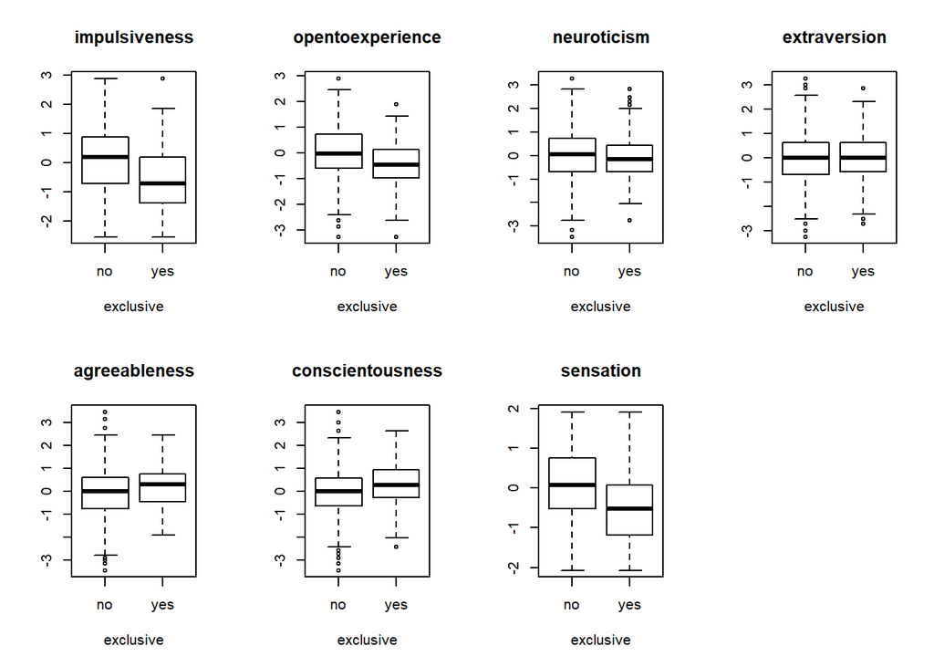

```r
par(mfrow=c(2,4))
plot(druguse$exclusive, druguse$impulsiveness,main='impulsiveness',xlab='exclusive')
plot(druguse$exclusive, druguse$opentoexperience,main='opentoexperience',xlab='exclusive')
plot(druguse$exclusive, druguse$neuroticism,main='neuroticism',xlab='exclusive')
plot(druguse$exclusive, druguse$extraversion,main='extraversion',xlab='exclusive')
plot(druguse$exclusive, druguse$agreeableness,main='agreeableness',xlab='exclusive')
plot(druguse$exclusive, druguse$conscientiousness,main='conscientousness',xlab='exclusive')
plot(druguse$exclusive, druguse$sensation,main='sensation',xlab='exclusive')
```

For my sanity, I decided to try a different model to see if I would have better luck:

```r
#NAIVE BAYES IMPLEMENTATION
mydrugs <- druguse
myperm=sample(nrow(druguse))
accuracy=0*(1:5) # initialise
fm = as.formula(druguse[c(37,1:16)])
for (n in 1:5) {
  inds=( (377*(n-1)+1):(377*n))
  thistest=mydrugs[myperm[inds],]
  thistrain=mydrugs[myperm[-inds],]
  model <- naiveBayes(fm ,data=thistrain)
  guess=predict(model, thistest)

  TP=sum(guess=='yes' & thistest$exclusive=='yes')
  TN=sum(guess=='no' & thistest$exclusive=='no')
  accuracy[n] = (TP+TN)/length(thistest$exclusive)
}
```

Let’s see if this is any better:

```r
table(guess,thistest[,37])
```

```
##
## guess  no yes
##   no  274  20
##   yes  63  20
```

```r
accuracy
```

```
## [1] 0.7877984 0.7904509 0.7957560 0.8116711 0.7798408
```

Not the greatest, but I’m satisfied.